# Tutorial_XGBoost

Jan-Niklas Tripp

29 6 2021

**eXtrem Gradient Boosting (XGBoost)**

Tree boosting is a widely used machine learning method and XGBoost use far fewer resources than existing systems. It`s usage went from advertising systems learn to match from users and their interests up to detecting anomaly events in physics that lead to new pyhsics (Chen, T., Guestrin, C. 2016, P. 1).

**Example for Decision Tree:**

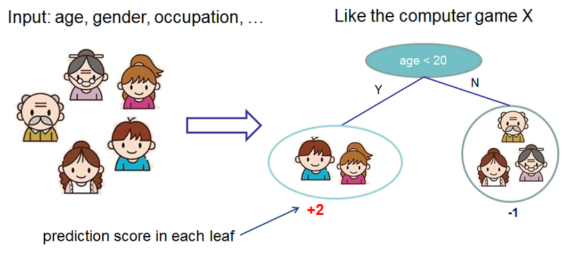

Note: Score in model is not the Gini impurity!

**Gradient Boost**

Creates a single leaf which represents an initial guess for a value of all of the samples. Out of the leaf it´s create a tree and build a next tree based on the errors made by the previous tree. Until it failed to fit or it created the trees you set at the beginning.

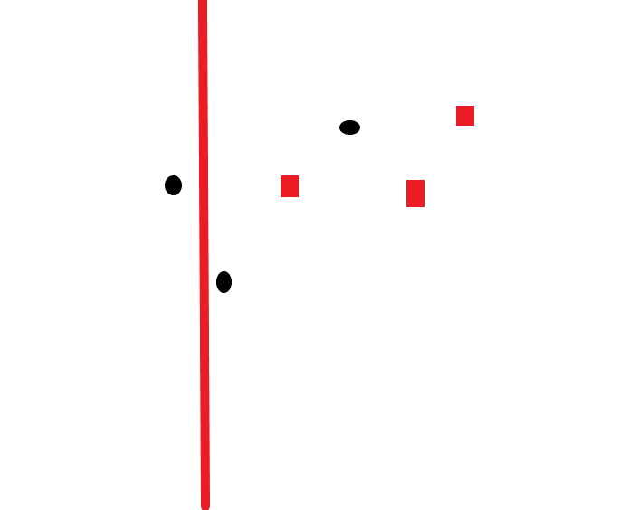

First Tree

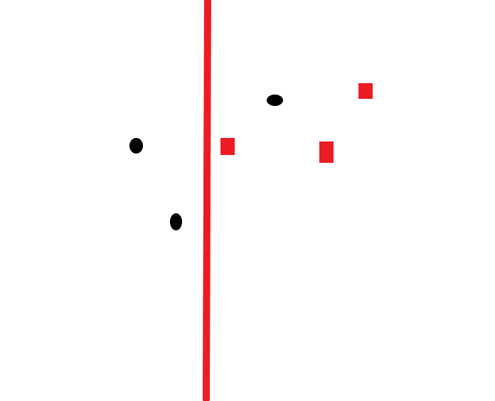

Second Tree

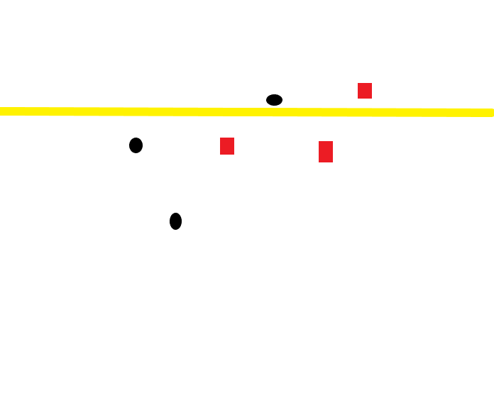

Third Tree

[video not shown]

Statquest Gradient Boost Part 1 (of 4): Regression Main Ideas

**XGBoost**

Does an initial prediction regardless of regression or classification. Use unique regression trees starting with one leaf. Leaf contains a similarity score of (lamdba). This scores used for calculating the gain. Higher gain = better split in a tree. Gamma can be used to prune Trees.

Lambda is a regularization parameter this results into a less higher sensitivity to individual observations. It also prevent the training data to over fitting.

Next tree will be created by learning rate “eta” (default setting is 0.3).

[video not shown]

Statquest XGBoost Part 1 (of 4): Regression

[XGBoost read the docs]: https://xgboost.readthedocs.io/en/latest/R-package/xgboostPresentation.html

**Data Preparation**

```r
#Loading Tools
library(xgboost)
library(raster)
#Check Workspace
getwd()
```

```
## [1] "C:/Users/Jan-Niklas Tripp/Desktop/SDM/XGBoost_Tutorial"
```

```r
#Set Workspace into created Folder
setwd("C:/Users/Jan-Niklas Tripp/Desktop/SDM/XGBoost_Tutorial")

##Data Preparation
#Loading the CSV Data
species_locations = read.csv("PakistanLadakh.csv", sep = ",")

#Check for Colnames
head(species_locations)
```

```
##       ï..species        x        y
## 1 Acraea_issoria 73.08635 34.43060
## 2 Acraea_issoria 73.36326 34.24367
## 3 Acraea_issoria 73.36758 34.14221
## 4 Acraea_issoria 73.82637 33.84266
## 5 Acraea_issoria 74.19839 33.94852
## 6  Acraea_violae 72.34951 31.70947
```

```r
#Change Colnames for readability
colnames(species_locations) = cbind("species", "long", "lat")

#Check for NA Values
summary(species_locations)
```

```
##    species               long            lat
##  Length:5870        Min.   :62.23   Min.   :24.13
##  Class :character   1st Qu.:71.90   1st Qu.:33.79
##  Mode  :character   Median :73.20   Median :34.74
##                     Mean   :72.71   Mean   :34.27
##                     3rd Qu.:73.93   3rd Qu.:35.94
##                     Max.   :77.78   Max.   :37.12
```

```r
#New Colnames check
head(species_locations)
```

```
##          species     long      lat
## 1 Acraea_issoria 73.08635 34.43060
## 2 Acraea_issoria 73.36326 34.24367
## 3 Acraea_issoria 73.36758 34.14221
## 4 Acraea_issoria 73.82637 33.84266
## 5 Acraea_issoria 74.19839 33.94852
## 6  Acraea_violae 72.34951 31.70947
```

```r
##A raster background map showing elevation data
#get ISO code for Pakistan
getData("ISO3")
```

```
##     ISO3                                         NAME
## 1    AFG                                  Afghanistan
## 2    XAD                        Akrotiri and Dhekelia
## 3    ALA                                        Åland
## 4    ALB                                      Albania
## 5    DZA                                      Algeria
## 6    ASM                               American Samoa
## 7    AND                                      Andorra
## 8    AGO                                       Angola
## 9    AIA                                     Anguilla
## 10   ATA                                   Antarctica
## 11   ATG                          Antigua and Barbuda
## 12   ARG                                    Argentina
## 13   ARM                                      Armenia
## 14   ABW                                        Aruba
```

[output cut: 242 more lines]

```r
#ISO code = PAK
elevation_PAK = getData("alt", country="PAK", level=0)

#Boundary of Pakistan for
boundary_PAK = getData("GADM", country="PAK", level=0)

show(boundary_PAK)
```

```
## class       : SpatialPolygonsDataFrame
## features    : 1
## extent      : 60.89944, 77.84308, 23.70292, 37.09701  (xmin, xmax, ymin, ymax)
## crs         : +proj=longlat +datum=WGS84 +no_defs +ellps=WGS84 +towgs84=0,0,0
## variables   : 2
## names       : GID_0,   NAME_0
## value       :   PAK, Pakistan
```

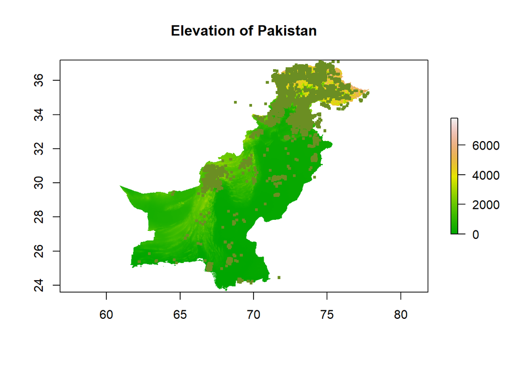

```r
#loading Bioclim Data Bio 2 around Pakistan
bioclim_data = getData(name = "worldclim",
                       var = "bio",
                       res = 2.5,
                       lon = 23.70292,
                       lat = 77.84308)[[c(2)]]

#Elevation Map
plot(elevation_PAK, main = "Elevation of Pakistan", col = terrain.colors(255))


#Checking if data are out of Pakistan
points(x = species_locations$long,
       y = species_locations$lat,
       col = "olivedrab",
       pch = 15,
       cex = 0.50)
```

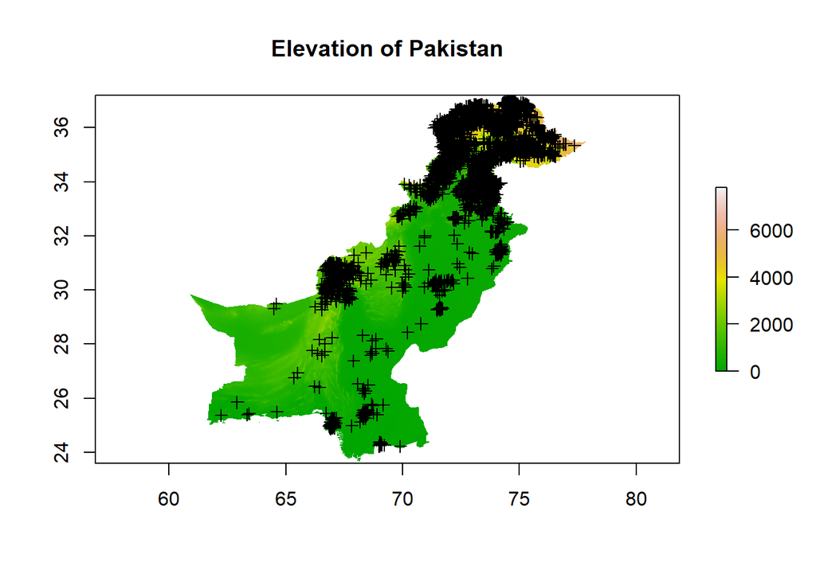

```r
#Convert to SP-DataFrame
coordinates(species_locations) = ~long+lat

#Setting CRS to Elevation Map
crs(species_locations) = crs(boundary_PAK)

#Crop species to Pakistan
crop_species_locations = crop(x = species_locations, y = boundary_PAK)

#Plot for checking
plot(elevation_PAK, main = "Elevation of Pakistan", col = terrain.colors(255))

plot(crop_species_locations, add = TRUE)
```

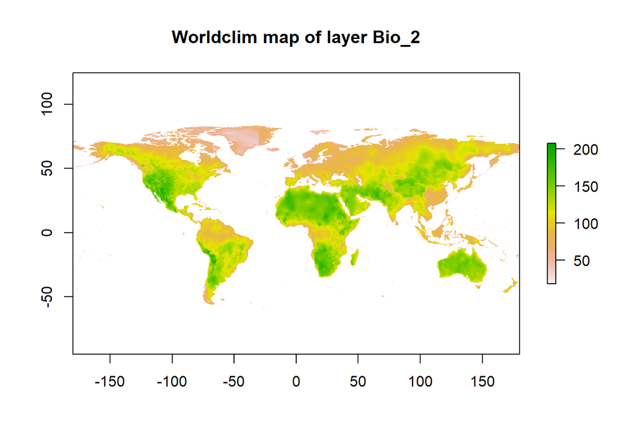

```r
#loading Bioclim Data Bio 2
bioclim_data = getData(name = "worldclim",
                       var = "bio",
                       res = 5)[[c(2)]]

plot(bioclim_data, main = "Worldclim map of layer Bio_2")
```

```r
#Shows extent of Pakistan
print(extent(boundary_PAK))
```

```
## class      : Extent
## xmin       : 60.89944
## xmax       : 77.84308
## ymin       : 23.70292
## ymax       : 37.09701
```

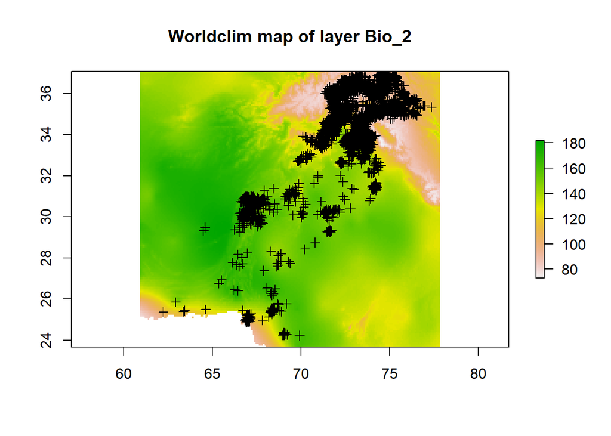

```r
#Create an extent Object which contains the max and min Values for Longitude and Latitude
extent_pak = extent(boundary_PAK)

#Use the extent via Crop Function on bioclim Data
bioclim_data = crop(bioclim_data, extent_pak) #bioclim_data = mask(bioclim_data, boundary_PAK)

#Test Plot for visual check
plot(bioclim_data, main = "Worldclim map of layer Bio_2")

plot(crop_species_locations, add = TRUE)
```

### What does XGBoost need?

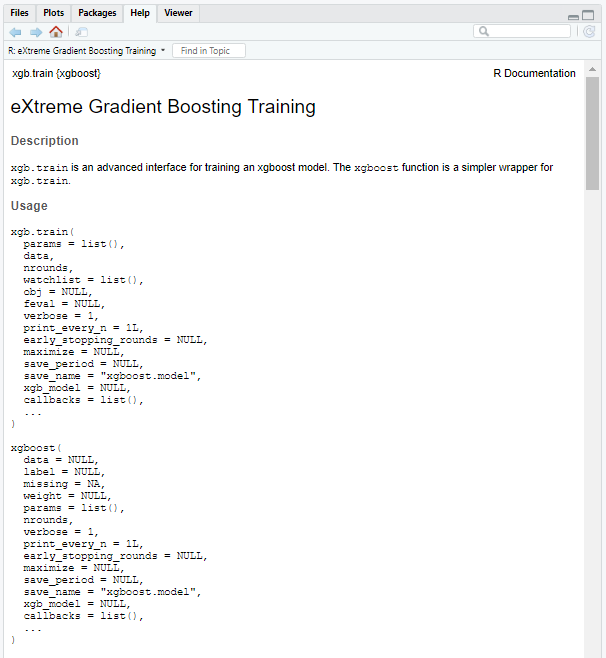

Head Documentation in R-Studio

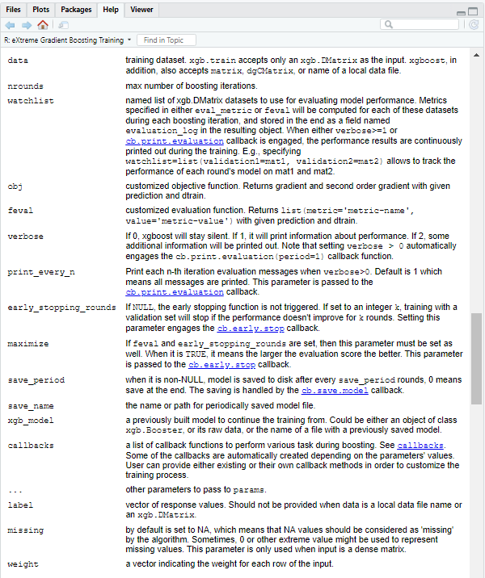

Closer look into Documentation in R-Studio

- Summary:* XGBoost needs a xgb.DMatrix, matrix dgCMatrix or name of a local data file. We need a vector for label otherwise XGBoost has no response Values. This mean we have to transform or data (Bioclim) into a matrix. We also have to transform our species(Labels) into Numbers.

**Example of XGBoost**

```r
#Matrix of bioclim_data
bio_values = extract(bioclim_data, extent_pak)
head(bio_values)
```

```
## [1] 140 140 140 140 139 140
```

```r
#Matrix of Values where our species are located
species_bio = extract(bioclim_data, crop_species_locations)
head(species_bio)
```

```
## [1] 121  90  89  99  88 148
```

```r
#Our train dataset.
train_bio = data.matrix(species_bio)
head(train_bio)
```

```
##      [,1]
## [1,]  121
## [2,]   90
## [3,]   89
## [4,]   99
## [5,]   88
## [6,]  148
```

```r
#Remember we need to transform our species (Char) into numeric values
#For this we have to convert the char in a factor and than into a number otherwise it contains only NA
classes = as.numeric(as.factor(crop_species_locations$species)) -1
head(classes)
```

```
## [1] 0 0 0 0 0 1
```

```r
#A very simple xgb model
xgb <- xgboost(booster="gbtree",
               data = train_bio,
               label = classes,
               eta = 0.3,
               max_depth = 6,
               nround=10,
               objective = "multi:softprob",
               num_class = length(unique(classes)),#Number of unique Classes = 421
               nthread = 3)
```

```
## [09:59:29] WARNING: amalgamation/../src/learner.cc:1095: Starting in XGBoost 1.3.0, the default evaluation metric used with the objective 'multi:softprob' was changed from 'merror' to 'mlogloss'. Explicitly set eval_metric if you'd like to restore the old behavior.
```

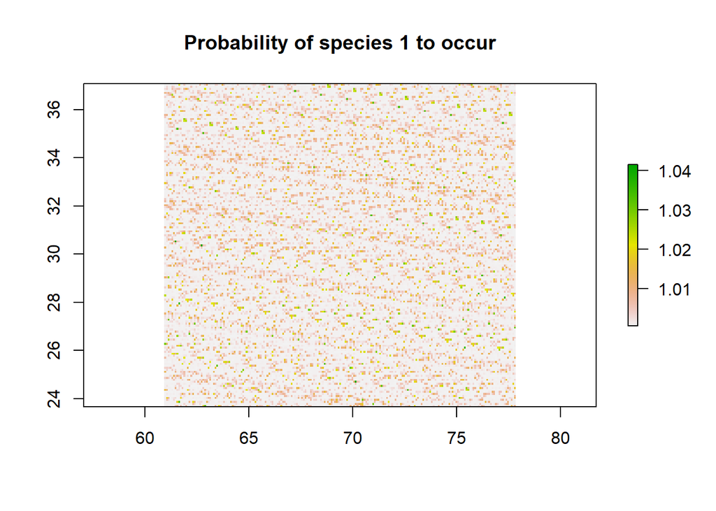

```r
#Use the Model on the Matrix of bioclim_data
result = predict(xgb, as.matrix(bio_values))

#Creating a raster with bioclim_data
res = raster(bioclim_data)

#Giving the raster the Values of Species 1 and their probability to occur in one Cell of the raster
res = setValues(res, result[1:32683]+1)

#Plotting the first Species
plot(res, main = "Probability of species 1 to occur")
```

**XGBoost with Train and Test data**

```r
#Set.seed ensures that we get the same sample
set.seed(1)

#Train index contain 25% random numbers in range of the length from species_bio
train_index = sample(length(species_bio), floor(0.25*length(species_bio)))
head(train_index)
```

```
## [1] 1017 4775 2177 5026 1533 4567
```

```r
#Train data contain 25% of the data of species_bio
train_data = species_bio[train_index]
head(train_index)
```

```
## [1] 1017 4775 2177 5026 1533 4567
```

```r
#Test data contain 75% of the data of species_bio
test_data = species_bio[-train_index]
head(test_data)
```

```
## [1] 121  90  89  99  88 148
```

```r
#Container for species classes
train_label = as.numeric(as.factor(classes[train_index]))-1

test_label = as.numeric(as.factor(classes[-train_index]))-1

#Container for species bio clim values
train_data2 = as.matrix(train_data)

test_data2 = as.matrix(test_data)

#Create an xgb model with train_data2
xgb_test <- xgboost(booster="gbtree",
               data = train_data2,
               label = train_label,
               eta = 0.9,
               max_depth = 8,
               nround=50,
               objective = "multi:softmax",#softprob doesn´t work with this set of data.
               num_class = length(unique(train_label)),
               nthread = 3)
```

```
## [09:59:36] WARNING: amalgamation/../src/learner.cc:1095: Starting in XGBoost 1.3.0, the default evaluation metric used with the objective 'multi:softmax' was changed from 'merror' to 'mlogloss'. Explicitly set eval_metric if you'd like to restore the old behavior.
```

```r
#Predict with the model classes in test_data
result2 = predict(xgb_test, test_data2)

head(test_label)
```

```
## [1] 0 0 0 0 0 1
```

```r
head(result2)
```

```
## [1] 132 235  41   3 204 111
```

**Just Predict 2 Species**

```r
#New container for species_locations
species1 = species_locations

#Transform species in species1 into numbers
species1$species = as.numeric(as.factor(species1$species))

#I choose the species 6 because it has 53 entries and added another one to the set
species1 = species1[species1$species==6 | species1$species==5,]
head(species1)
```

```
##    species
## 16       5
## 17       5
## 18       5
## 19       5
## 20       5
## 21       5
```

```r
species1_bio = extract(bioclim_data, species1)

#Set class value of species 5 to 0
species1[species1$species==5,] = 0
head(species1)
```

```
##    species
## 16       0
## 17       0
## 18       0
## 19       0
## 20       0
## 21       0
```

```r
set.seed(2)

#Train index contain 25% random numbers in range of the length from species1
train_index2 = sample(length(species1), floor(0.25*length(species1)))
head(train_index2)
```

```
## [1] 21 15  6 60 32  8
```

```r
#Train data contain 25% of the data of species1_bio
train_data3 = species1_bio[train_index2]
head(train_index2)
```

```
## [1] 21 15  6 60 32  8
```

```r
#Test data contain 75% of the data of species1_bio
test_data3 = species1_bio[-train_index2]
head(test_data2)
```

```
##      [,1]
## [1,]  121
## [2,]   90
## [3,]   89
## [4,]   99
## [5,]   88
## [6,]  148
```

```r
#Container for species classes
train_label2 = as.numeric(as.factor(species1$species[train_index2]))-1

test_label2 = as.numeric(as.factor(species1$species[-train_index2]))-1

#Container for species bio clim values
train_data4 = as.matrix(train_data3)

test_data4 = as.matrix(test_data3)


#Create an xgb model with train_data2
xgb_test <- xgboost(booster="gbtree",
               data = train_data4,
               label = train_label2,
               eta = 0.1,
               max_depth = 6,
               nround=10,
               objective = "binary:hinge",
               num_class = length(unique(train_label2))-1,
               nthread = 4)
#Predict with the model classes in test_data
result3 = predict(xgb_test, test_data4)

head(test_label2)
```

```
## [1] 0 0 0 0 0 1
```

```r
head(result3)
```

```
## [1] 0 0 0 1 0 0
```

```r
#Wow it looks perfect! Too perfect...
#Lets do a prediction with all data
result_perf = predict(xgb_test, as.matrix(bio_values))

#Check what it predict for every Cell
summary(result_perf)
```

```
##    Min. 1st Qu.  Median    Mean 3rd Qu.    Max.
##  0.0000  1.0000  1.0000  0.9144  1.0000  1.0000
```

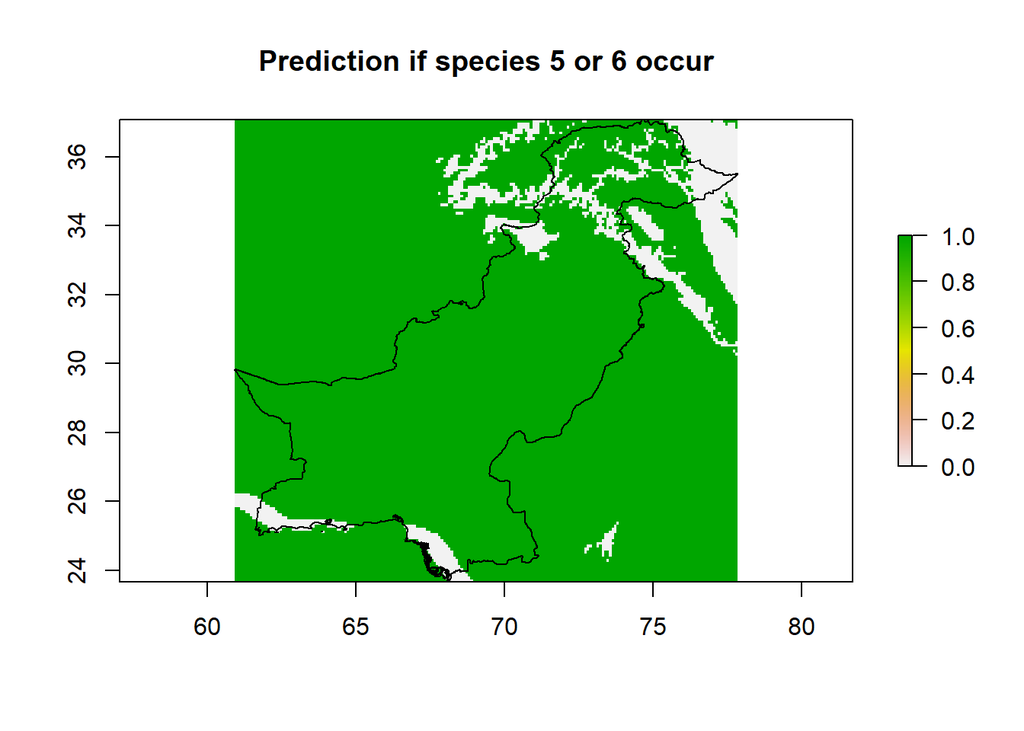

```r
res2 = raster(bioclim_data)

res2 = setValues(res2, result_perf)

plot(res2, main = "Prediction if species 5 or 6 occur")
plot(boundary_PAK, add = TRUE)
```

Sources: StatQuest with Josh Starmer (22.01.2018): StatQuest: Decision Trees. https://www.youtube.com/watch?v=7VeUPuFGJHk (Zugriff: 28.06.2021).

StatQuest with Josh Starmer (16.12.2019): XGBoost Part 1 (of 4): Regression. https://www.youtube.com/watch?v=OtD8wVaFm6E&t=213s (Zugriff: 28.06.2021).

StatQuest with Josh Starmer (13.01.2020): XGBoost Part 2 (of 4): Classification. https://www.youtube.com/watch?v=8b1JEDvenQU&t=923s (Zugriff: 28.06.2021).

StatQuest with Josh Starmer (25.03.2019): Gradient Boost Part 1 (of 4): Regression Main Ideas. https://www.youtube.com/watch?v=3CC4N4z3GJc (Zugriff:28.06.2021).

Chen, T., Guestrin, C. (2016): XGBoost: A Scalable Tree Boosting System. https://arxiv.org/pdf/1603.02754.pdf (Zugriff: 15.06.2021).